# Análise de Dados do navio Titanic

Nesse projeto serão analisados os dados provenientes do site [Titanic: Machine Learning from Disaster](https://www.kaggle.com/c/titanic/data), baseando-se em perguntas chave com a principal finalidade de *Descobrir quais foram os fatores que permitiram a sobrevivência ou não dos passageiros a bordo do navio Titanic*.

# Verificação Inicial dos Dados

Para que seja possível de analisar corretamente os dados, é necessário inicialmente o entendimento correto dos dados com os quais serão trabalhados. Portanto, nesse tópico serão apontadas algumas informações relacionadas aos dados a serem usados nessa análise

```python
#Execute esse bloco inicialmente, pois é necessário para o funcionamento dos demais
import pandas as pd
import numpy as np
import matplotlib.pyplot as plt

%matplotlib inline
```

Para isso, inicia-se com a visualização da tabela, juntamente com os tipos de dados que serão lidados:

```python
titanic_dados = pd.read_csv("titanic-data.csv", index_col = 'PassengerId')
display(titanic_dados.head(10))
print("Quantidade de Amostras: {0}\t Quantidade de Atributos: {1}".format(titanic_dados.shape[0],titanic_dados.shape[1]))
```

| PassengerId | Survived | Pclass | Name | Sex | Age | SibSp | Parch | Ticket | Fare | Cabin | Embarked |
| --- | --- | --- | --- | --- | --- | --- | --- | --- | --- | --- | --- |
| 1 | 0 | 3 | Braund, Mr. Owen Harris | male | 22.0 | 1 | 0 | A/5 21171 | 7.2500 | NaN | S |
| 2 | 1 | 1 | Cumings, Mrs. John Bradley (Florence Briggs Th... | female | 38.0 | 1 | 0 | PC 17599 | 71.2833 | C85 | C |
| 3 | 1 | 3 | Heikkinen, Miss. Laina | female | 26.0 | 0 | 0 | STON/O2. 3101282 | 7.9250 | NaN | S |
| 4 | 1 | 1 | Futrelle, Mrs. Jacques Heath (Lily May Peel) | female | 35.0 | 1 | 0 | 113803 | 53.1000 | C123 | S |
| 5 | 0 | 3 | Allen, Mr. William Henry | male | 35.0 | 0 | 0 | 373450 | 8.0500 | NaN | S |
| 6 | 0 | 3 | Moran, Mr. James | male | NaN | 0 | 0 | 330877 | 8.4583 | NaN | Q |
| 7 | 0 | 1 | McCarthy, Mr. Timothy J | male | 54.0 | 0 | 0 | 17463 | 51.8625 | E46 | S |
| 8 | 0 | 3 | Palsson, Master. Gosta Leonard | male | 2.0 | 3 | 1 | 349909 | 21.0750 | NaN | S |
| 9 | 1 | 3 | Johnson, Mrs. Oscar W (Elisabeth Vilhelmina Berg) | female | 27.0 | 0 | 2 | 347742 | 11.1333 | NaN | S |
| 10 | 1 | 2 | Nasser, Mrs. Nicholas (Adele Achem) | female | 14.0 | 1 | 0 | 237736 | 30.0708 | NaN | C |

```
Quantidade de Amostras: 891	 Quantidade de Atributos: 11
```

De acordo com o site da Kaggle, cada dado pode ser relacionado através da coluna **PassengerId**, com os seguintes atributos:

**Survived**: onde *0 = Não Sobreviveu e* 1 = Sobreviveu*;

**Pclass**: diz respeito ao Nível Socio-Econômico do passageiro, onde *1 = Classe Alta*, *2 = Classe Média* e *3 = Classe Baixa*;

**Name**: Nome do Passageiro;

**Sex**: Gênero do Passageiro;

**Age**: Idade do Passageiro;

**SibSp**: Quantidade de Irmãos ou Cônjuges(exceto Amantes e Noivas(os)) que o Passageiro possuía a bordo do navio;

**Parch**: Quantidade de Parentes, como Pais, e Crianças, como Filhos ou Enteados (**OBS**: Em alguns casos as crianças passageiras foram apenas com a babá, sendo considerado nesses casos como *Parch = 0*);

**Ticket**: Número do Ticket de embarcação do Passageiro;

**Fare**: Tarifa paga pelos Passageiros;

**Cabin**: Número da Cabine;

**Embarked**: Porto da Embarcação do Passageiro, onde *C = Cherbourg*, *Q = Queenstown* e *S = Southampton*.

Agora, descobriremos os tipos de dados que cada coluna armazena:

```python
#Método retirado dos exemplos do curso para verificar os tipos das colunas:
for column in titanic_dados.columns:
        print("coluna: {0}, tipo: {1}".format(column, type(titanic_dados[column][1])))
```

```
coluna: Survived, tipo: <class 'numpy.int64'>
coluna: Pclass, tipo: <class 'numpy.int64'>
coluna: Name, tipo: <class 'str'>
coluna: Sex, tipo: <class 'str'>
coluna: Age, tipo: <class 'numpy.float64'>
coluna: SibSp, tipo: <class 'numpy.int64'>
coluna: Parch, tipo: <class 'numpy.int64'>
coluna: Ticket, tipo: <class 'str'>
coluna: Fare, tipo: <class 'numpy.float64'>
coluna: Cabin, tipo: <class 'float'>
coluna: Embarked, tipo: <class 'str'>
```

Por fim, visualizamos um breve resumo relacionado aos dados adquridos:

```python
titanic_dados.describe()
```

|  | Survived | Pclass | Age | SibSp | Parch | Fare |
| --- | --- | --- | --- | --- | --- | --- |
| count | 891.000000 | 891.000000 | 714.000000 | 891.000000 | 891.000000 | 891.000000 |
| mean | 0.383838 | 2.308642 | 29.699118 | 0.523008 | 0.381594 | 32.204208 |
| std | 0.486592 | 0.836071 | 14.526497 | 1.102743 | 0.806057 | 49.693429 |
| min | 0.000000 | 1.000000 | 0.420000 | 0.000000 | 0.000000 | 0.000000 |
| 25% | 0.000000 | 2.000000 | 20.125000 | 0.000000 | 0.000000 | 7.910400 |
| 50% | 0.000000 | 3.000000 | 28.000000 | 0.000000 | 0.000000 | 14.454200 |
| 75% | 1.000000 | 3.000000 | 38.000000 | 1.000000 | 0.000000 | 31.000000 |
| max | 1.000000 | 3.000000 | 80.000000 | 8.000000 | 6.000000 | 512.329200 |

# Perguntas acerca dos dados

Nesse tópico serão mostrados as principais perguntas relacionados ao objetivo final e com base no conjunto de dados mostrado anteriormente:

**1)** A classe econômica dos passageiros poderia contribuir para sua chance de sobreviência?

**2)** Passageiros solitários tiveram maiores chances de sobreviver?

**3)** Qual gênero que teve maior número de sobreviventes?

**4)** As crianças ou os adultos que obtiveram maior índice de sobrevivência?

# Limpeza e Tratamento dos Dados

Antes de começarmos a analisar e responder às perguntas, é necessário antes limparmos e tratarmos todos os dados para que possamos usá-los da melhor maneira possível.

## Valores Nulos

Começaremos com a verificação das lihas com valores nulos nos dados:

```python
titanic_dados.isna().sum()
```

```
Survived      0
Pclass        0
Name          0
Sex           0
Age         177
SibSp         0
Parch         0
Ticket        0
Fare          0
Cabin       687
Embarked      2
dtype: int64
```

Como podemos ver, apenas três atributos possuem dados nulos: `Age`, com 177 valores nulos, `Cabin`, com 687 e `Embarked`, com 2.

No caso dos atributos `Cabin` e `Embarked`, eles não serão necessários para a descoberta das respostas das perguntas acerca dos dados, portanto podem ser removidos do dataset:

```python
titanic_dados.drop(["Cabin", "Embarked"], axis = 1, inplace = True)
```

```python
titanic_dados.head()
```

| PassengerId | Survived | Pclass | Name | Sex | Age | SibSp | Parch | Ticket | Fare |
| --- | --- | --- | --- | --- | --- | --- | --- | --- | --- |
| 1 | 0 | 3 | Braund, Mr. Owen Harris | male | 22.0 | 1 | 0 | A/5 21171 | 7.2500 |
| 2 | 1 | 1 | Cumings, Mrs. John Bradley (Florence Briggs Th... | female | 38.0 | 1 | 0 | PC 17599 | 71.2833 |
| 3 | 1 | 3 | Heikkinen, Miss. Laina | female | 26.0 | 0 | 0 | STON/O2. 3101282 | 7.9250 |
| 4 | 1 | 1 | Futrelle, Mrs. Jacques Heath (Lily May Peel) | female | 35.0 | 1 | 0 | 113803 | 53.1000 |
| 5 | 0 | 3 | Allen, Mr. William Henry | male | 35.0 | 0 | 0 | 373450 | 8.0500 |

Agora precisamos tratar os dados nulos da coluna `Age`. Como ela é necessária para nossa análise de dados, não podemos simplesmente deletar essa coluna. Para resolver o problema da falta de dados, faremos com que esses campos nulos recebam a média das idades presentes nessa coluna:

**OBS**: Apesar de o tipo de dado armazenado na coluna `Age` ser do tipo *float*(decimal), para melhor visualização, arredondaremos a média para a sua correta inserção dentro dos valores nulos.

```python
#Inserção de dados nos campos nulos:
titanic_dados['Age'].fillna(round(titanic_dados['Age'].mean(),0), inplace = True)
print("Valor a ser substituído nos campos nulos: {0}".format(round(titanic_dados['Age'].mean())))
```

```
Valor a ser substituído nos campos nulos: 30
```

Vejamos agora se de fato todos os campos nulos de `Age` foram preenchidos de fato:

```python
titanic_dados.isna().sum()
```

```
Survived    0
Pclass      0
Name        0
Sex         0
Age         0
SibSp       0
Parch       0
Ticket      0
Fare        0
dtype: int64
```

Pronto! Não tem mais nenhum dado nulo no conjunto de dados!

## Dados Duplicados

Verificaremos agora a quantidade de linhas duplicadas que há no conjunto de dados:

```python
titanic_dados.duplicated().sum()
```

```
0
```

Como não há nenhum dado duplicado, não será necessário nenhum tratamento quanto a esse problema.

## Finalizando a Limpeza e Tratamento de Dados

Com a finalização da limpeza dos dados, agora é necessário termos ele disponível sempre que quisermos. Portanto, a última etapa desse tópico é a criação de um arquivo CSV para armazenar esses dados tratados:

**OBS**: Apesar de tentador, não é recomendável que substitua o arquivo original pelo tratado. Afinal, nunca se sabe quais outras surgirão com base nesse dataset, e de outras formas serão necessárias tratar esse conjunto de dados.

```python
#Criação do Arquivo CSV com os dados tratados:
titanic_dados.to_csv("titanic-data-novos1.csv")
```

# Pergunta 1: A classe econômica dos passageiros poderia contribuir para sua chance de sobreviência?

Para respondermos essa pergunta, precisamos inicialmente verificar a situação de cada passaageiro que sobreviveu ou não de acordo com a coluna `Pclass`:

```python
titanic_dados.groupby(['Pclass', titanic_dados['Survived'] == 1]).count()['Survived']
```

```
Pclass  Survived
1       False        80
        True        136
2       False        97
        True         87
3       False       372
        True        119
Name: Survived, dtype: int64
```

Uma outra forma de visualização seria através de um gráfico de barras:

```
<BarContainer object of 3 artists>
```

```
Text(0,0.5,'Quantidade de Sobreviventes')
```

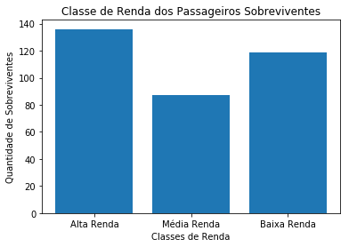

```python
renda = [titanic_dados.query("Pclass == 1 and Survived == 1"), titanic_dados.query("Pclass == 2 and Survived == 1"),
         titanic_dados.query("Pclass == 3 and Survived == 1")]
dados_renda = [renda[0]["Survived"].count(), renda[1]["Survived"].count(), renda[2]["Survived"].count()]
posicoes = [1, 2, 3]
nomenclatura = ['Alta Renda', 'Média Renda', 'Baixa Renda']

display(plt.bar(posicoes, dados_renda, tick_label = nomenclatura))
plt.title("Classe de Renda dos Passageiros Sobreviventes")
plt.xlabel("Classes de Renda")
plt.ylabel("Quantidade de Sobreviventes")
```

Como podemos ver, a maioria dos passageiros da classe alta, ou `Pclass = 1`, conseguiram sobreviver, seguidos da classe baixa e por último a classe média. Apesar de a classe média ter tido um número menor de sobreviventes, a classe baixa teve uma quantidade maior de mortos do que as duas outras classes juntas. Portanto, **o fator econômico poderia ter contribuído para as chances de sobrevivência dos passageiros, aonde pessoas com Alta Renda pode ter tido mais oportunidades de resgate que às de Média e Baixa Renda**.

# Pergunta 2: Passageiros solitários tiveram maiores chances de sobreviver?

Para respondermos a essa pergunta, precisamos realizar o mesmo tipo de interação, porém com as colunas `SibSp` e `Parch`:

```python
titanic_dados.groupby(['Parch', 'SibSp', titanic_dados['Survived'] == 1]).count()['Survived']
```

```
Parch  SibSp  Survived
0      0      False       374
              True        163
       1      False        59
              True         64
       2      False        12
              True          4
       3      True          2
1      0      False        13
              True         25
       1      False        23
              True         34
       2      False         1
              True          6
       3      False         7
       4      False         9
2      0      False         8
              True         21
       1      False         7
              True         12
       2      False         2
              True          2
       3      False         5
              True          2
       4      False         6
              True          3
       5      False         5
       8      False         7
3      0      True          1
       1      False         2
              True          1
       2      True          1
4      0      False         1
       1      False         3
5      0      False         2
       1      False         2
              True          1
6      1      False         1
Name: Survived, dtype: int64
```

Essa relação ficou bem confusa e difícil de se analisar os dados. Por isso, criaremos uma nova coluna, chamada `Familiares`, com os valores de cada linha relacionados às duas colunas:

```python
titanic_dados['Familiares'] = titanic_dados['SibSp'] + titanic_dados['Parch']
display(titanic_dados.head(10))
```

| PassengerId | Survived | Pclass | Name | Sex | Age | SibSp | Parch | Ticket | Fare | Familiares |
| --- | --- | --- | --- | --- | --- | --- | --- | --- | --- | --- |
| 1 | 0 | 3 | Braund, Mr. Owen Harris | male | 22.0 | 1 | 0 | A/5 21171 | 7.2500 | 1 |
| 2 | 1 | 1 | Cumings, Mrs. John Bradley (Florence Briggs Th... | female | 38.0 | 1 | 0 | PC 17599 | 71.2833 | 1 |
| 3 | 1 | 3 | Heikkinen, Miss. Laina | female | 26.0 | 0 | 0 | STON/O2. 3101282 | 7.9250 | 0 |
| 4 | 1 | 1 | Futrelle, Mrs. Jacques Heath (Lily May Peel) | female | 35.0 | 1 | 0 | 113803 | 53.1000 | 1 |
| 5 | 0 | 3 | Allen, Mr. William Henry | male | 35.0 | 0 | 0 | 373450 | 8.0500 | 0 |
| 6 | 0 | 3 | Moran, Mr. James | male | 30.0 | 0 | 0 | 330877 | 8.4583 | 0 |
| 7 | 0 | 1 | McCarthy, Mr. Timothy J | male | 54.0 | 0 | 0 | 17463 | 51.8625 | 0 |
| 8 | 0 | 3 | Palsson, Master. Gosta Leonard | male | 2.0 | 3 | 1 | 349909 | 21.0750 | 4 |
| 9 | 1 | 3 | Johnson, Mrs. Oscar W (Elisabeth Vilhelmina Berg) | female | 27.0 | 0 | 2 | 347742 | 11.1333 | 2 |
| 10 | 1 | 2 | Nasser, Mrs. Nicholas (Adele Achem) | female | 14.0 | 1 | 0 | 237736 | 30.0708 | 1 |

Agora, faremos de novo àquela interação, porém relacionado à coluna `Familiares`:

```python
titanic_dados.groupby(['Familiares', titanic_dados['Survived'] == 1]).count()['Survived']
```

```
Familiares  Survived
0           False       374
            True        163
1           False        72
            True         89
2           False        43
            True         59
3           False         8
            True         21
4           False        12
            True          3
5           False        19
            True          3
6           False         8
            True          4
7           False         6
10          False         7
Name: Survived, dtype: int64
```

Uma outra maneira menos confusa de verificar os sobreviventes seria essa:

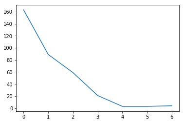

```python
familiares = titanic_dados[titanic_dados['Survived'] == 1].groupby(['Familiares']).count()['Survived']
display(plt.plot(familiares))
```

# Pergunta 3: Qual gênero que teve maior número de sobreviventes?

Primeiramente é necessário a análise dos sexos em relação aos sobreviventes, agora com as colunas `Survived` e `Sex`:

```python
titanic_dados.query('Survived == 1').groupby(['Sex'])['Sex'].count()
```

```
Sex
female    233
male      109
Name: Sex, dtype: int64
```

Além disso, temos também o gráfico para visualizarmos melhor:

```
<BarContainer object of 2 artists>
```

```
Text(0,0.5,'Sobreviventes')
```

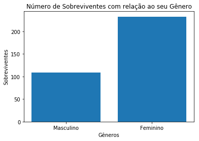

```python
genero = [titanic_dados.query("Sex == 'male' and Survived == 1"), titanic_dados.query("Sex == 'female' and Survived == 1")]
posicoes = [1, 2]
nomenclatura  = ['Masculino', 'Feminino']
dados_genero = [genero[0]['Survived'].count(), genero[1]['Survived'].count()]

display(plt.bar(posicoes, dados_genero, tick_label = nomenclatura))
plt.title("Número de Sobreviventes com relação ao seu Gênero")
plt.xlabel("Gêneros")
plt.ylabel("Sobreviventes")
```

Portanto, como visto tanto pelos números quanto pelo próprio gráfico, **o gênero feminino teve maior quantidade de sobreviventes** do que o masculino. Essa informação pode levar em conta a política emergêncial de *"Mulheres e crianças são sempre os primeiros a sair"*, devido também aos preceitos da época.

# Pergunta 4: As crianças ou os adultos que obtiveram maior índice de sobrevivência?

Primeiramente temos que ter um parâmetro relacionado à infância e maturidade: partindo do pressuposto dos preceitos da época, iremos considerar a fase madura como sendo a partir dos 17 anos. Partindo desse parâmetro, iremos inicialmente relacionar os sobreviventes com menos de 17 e os de 17 anos ou mais:

```python
#Lista com as consultas dos sobreviventes menores de 17 e maiores ou iguais à 17 anos.
maturidade = [titanic_dados.query("Age < 17 and Survived == 1"), titanic_dados.query("Age >= 17 and Survived == 1")]
criancas = maturidade[0]['Survived'].count()
adultos = maturidade[1]['Survived'].count()
print("O número de crianças(menores que 17 anos) sobreviventes é {0}.\nO número de adultos(maiores ou iguais a 17 anos) sobreviventes é {1}."
      .format(criancas, adultos))
```

```
O número de crianças(menores que 17 anos) sobreviventes é 55.
O número de adultos(maiores ou iguais a 17 anos) sobreviventes é 287.
```

A relação das idades nos mostrou que o número de sobreviventes maiores ou iguais a 17 anos é maior que os menores de 17. Contudo, seria mais informativo que também soubéssemos a quantidade de passageiros menores e maiores ou iguais a 17 anos:

```python
criancas_totais = titanic_dados.query("Age < 17").count()['Age']
adultos_totais = titanic_dados.query("Age >= 17").count()['Age']

print("O número de crianças a bordo do Titanic foi {0}.\nO número de adultos a bordo do Titanic foi {1}."
      .format(criancas_totais, adultos_totais))
```

```
O número de crianças a bordo do Titanic foi 100.
O número de adultos a bordo do Titanic foi 791.
```

Agora que nos foi apresentado a quantidade total de passageiros adultos e crianças, pode-se ter uma conclusão mais precisa acerca da quantidade de sobreviventes de cada categoria.

Para finalizar nossa análise, e podermos enfim chegar a uma conclusão, vamos visualizar o gráfico de sobreviventes de cada categoria:

```
<BarContainer object of 2 artists>
```

```
Text(0,0.5,'Sobreviventes')
```

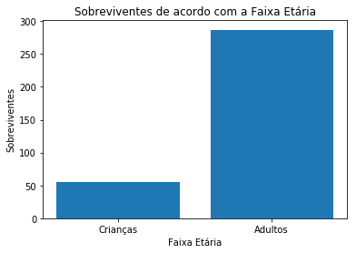

```python
posicoes = [1, 2]
nomenclatura = ["Crianças", "Adultos"]
dados_idade = [criancas, adultos]

display(plt.bar(posicoes, dados_idade, tick_label = nomenclatura))
plt.title("Sobreviventes de acordo com a Faixa Etária")
plt.xlabel("Faixa Etária")
plt.ylabel("Sobreviventes")
```

Portanto, ao olhar todas as informações analisadas, podemos concluir que **o número de adultos sobreviventes é maior que o número de crianças sobreviventes**. Com o intuito de autenticar esses dados, fizemos também a contagem total de passageiros que passageiros presentes no conjunto de dados, e observamos o mesmo comportamento, aonde o número de adultos foi maior que o número de crianças a bordo do navio. Portanto, esse poderia considerado um resultado esperado, tendo em vista que inicialmente já haviam mais adultos que crianças a bordo.

# Conclusão Final

Com a análise de todos os dados e afirmações adquiridas com essa análise, iremos finalizar com uma afirmação mais completa, aonde podemos concluir que o principal perfil de um sobrevivente em geral são **Passageiros do Sexo *Feminino*, de *Alta Renda*, presente na Faixa Etária *Adulta, ou seja, acima dos 17 anos*, tendo *poucos ou nenhum Familiar* a bordo do navio**.